# Microbiome data analysis with microViz

Intro & Diversity

David Barnett

2022-05-30

# Setup

```r
library(seriation)
library(dplyr)
library(purrr)
library(ggplot2)
library(phyloseq)
library(microViz)
library(shiny)
```

```r
mice <- readRDS(here::here('data/mice.rds'))
shao19 <- readRDS(here::here('data/shao19.rds'))
```

We’ll use two datasets today, both are about the gut microbiome. The first is from a study of antibiotic administration in mice, and the second is from a large birth cohort study in human infants.

Each dataset was generated using different sequencing techniques, and different sequence data processing approaches. But the analyses approaches we will learn today can be readily applied to both methods. (The approaches are also appropriate for data other than the gut microbiota!)

- `mice` is 16S rRNA gene amplicon sequencing data, from the mouse antibiotics study
  - They used Illumina MiSeq and processed the data into ASVs using DADA2
- `shao19` is shotgun metagenomic data, from a 2019 study of infants born vaginally or by C-section.
  - They used Illumina HiSeq and the abundance of species-like features was inferred with metaphlan3.

So the data has already been processed from fastq files into counts per taxon. This is the exciting bit, you get to explore and visualize the data, and do statistics (yay!).

# Intro to phyloseq

This is a `phyloseq` S4 object, containing processed microbiota data from the mouse study.

**Click here for more details about the mice dataset:**

**The mice data**

The data originate from a study on the effects of oral antibiotic administration on flavivirus infection (https://www.ncbi.nlm.nih.gov/pubmed/29590614). Sequence data was generated from extracted nucleic acid from stool samples collected from individually caged mice and amplified using primers specific for the V4 region using primers 515F/806R.

The study followed flavivirus infection after the following treatments:

1. Koolaid: Antibiotics are provided to the mice via their drinking water. As many of the antibiotics taste bad, koolaid is added as a sweetener. Therefore, the appropriate control is water spiked and labelled *koolaid*.
2. Ampicillin (Amp): https://en.wikipedia.org/wiki/Ampicillin
3. Metronidazole (Met): https://en.wikipedia.org/wiki/Metronidazole
4. Ampicillin + Metronidazole (Amp+Metro)

Treatments were supplied ad libitum for 2 weeks prior to viral infection and maintained for 2 weeks post-infection. Primary outcome was mouse survival. Each treatment group had two subgroups of mice that were either a) left uninfected as controls or b) infected with West Nile Virus via a subcutaneous foot pad injection.

Get a little familiar with the object. What does it have in it? Can you look at each part?

The printed object shows you functions you can use to access the data inside.

You can also use the `@` symbol.

```r
mice
```

```
## phyloseq-class experiment-level object
## otu_table()   OTU Table:         [ 3229 taxa and 520 samples ]
## sample_data() Sample Data:       [ 520 samples by 11 sample variables ]
## tax_table()   Taxonomy Table:    [ 3229 taxa by 7 taxonomic ranks ]
```

```r
# View(mice)
```

```r
tax_table(mice) %>% head()
```

```
## Taxonomy Table:     [6 taxa by 7 taxonomic ranks]:
##         Kingdom    Phylum           Class                 Order
## ASV0001 "Bacteria" "Bacteroidetes"  "Bacteroidia"         "Bacteroidales"
## ASV0002 "Bacteria" "Proteobacteria" "Gammaproteobacteria" "Xanthomonadales"
## ASV0003 "Bacteria" "Bacteroidetes"  "Bacteroidia"         "Bacteroidales"
## ASV0004 "Bacteria" "Bacteroidetes"  "Bacteroidia"         "Bacteroidales"
## ASV0005 "Bacteria" "Bacteroidetes"  "Bacteroidia"         "Bacteroidales"
## ASV0006 "Bacteria" "Bacteroidetes"  "Bacteroidia"         "Bacteroidales"
##         Family               Genus              Species
## ASV0001 "Porphyromonadaceae" NA                 NA
## ASV0002 "Xanthomonadaceae"   "Stenotrophomonas" "maltophilia"
## ASV0003 "Porphyromonadaceae" NA                 NA
## ASV0004 "Porphyromonadaceae" NA                 NA
## ASV0005 "Porphyromonadaceae" NA                 NA
## ASV0006 "Porphyromonadaceae" NA                 NA
```

```r
rank_names(mice)
```

```
## [1] "Kingdom" "Phylum"  "Class"   "Order"   "Family"  "Genus"   "Species"
```

```r
otu_table(mice)[1:15, 1:8]
```

```
## OTU Table:          [8 taxa and 15 samples]
##                      taxa are columns
##        ASV0001 ASV0002 ASV0003 ASV0004 ASV0005 ASV0006 ASV0007 ASV0008
## D14.A1    3343       0    4205    3470    3607    1210    1159    1852
## D14.B5    4332       0    5412    2494    3083    1451    1663    1745
## D0.D5     5344       0    3906    1439    2396    1402    1217    2078
## D0.E1     2994       0    4005    2188    2882    1267    1821    1788
## D0.E2     2315       0    3987     955    1665    1025     899    1342
## D0.E3     1972       0    4336    1876    3422    1208     551    1900
## D0.E4     2352       0    2561    1960    2060    1350    1095    1200
## D0.E5     1386       0    1752    1471    1363     724    1050     871
## D0.F1     3795       0    4052    2226    3130     539     162     247
## D0.F2     2867       0    2063     435    1412     410       0     150
## D0.F3     3850       0    4203     508    2839     533       0     230
## D0.F4     6740       0    5045    1356    5755     517      85     210
## D14.C1    2664       3    2892    1530    2176     735    1508    1577
## D0.F5     5303       3    4203    3313    4471    1241     344     441
## D0.G1     3052       0    3393    3209    2867     873     372    1512
```

```r
# mice@otu_table[1:15, 1:10] # the same result
```

```r
sample_variables(mice)
```

```
##  [1] "sample_id"       "barcode"         "run"             "plate"
##  [5] "sample"          "sex"             "cage"            "treatment_days"
##  [9] "treatment"       "virus"           "survival_status"
```

```r
sample_data(mice)[1:15, 1:5]
```

```
##                 sample_id      barcode run plate sample
## D14.A1  1.Thackray.D14.A1 ACGAGACTGATT 368     1      1
## D14.B5 10.Thackray.D14.B5 ACCGGTATGTAC 368     1     10
## D0.D5  100.Thackray.D0.D5 ATCTACCGAAGC 368     2    100
## D0.E1  101.Thackray.D0.E1 ACTTGGTGTAAG 368     2    101
## D0.E2  102.Thackray.D0.E2 TCTTGGAGGTCA 368     2    102
## D0.E3  103.Thackray.D0.E3 TCACCTCCTTGT 368     2    103
## D0.E4  104.Thackray.D0.E4 GCACACCTGATA 368     2    104
## D0.E5  105.Thackray.D0.E5 GCGACAATTACA 368     2    105
## D0.F1  106.Thackray.D0.F1 TCATGCTCCATT 368     2    106
## D0.F2  107.Thackray.D0.F2 AGCTGTCAAGCT 368     2    107
## D0.F3  108.Thackray.D0.F3 GAGAGCAACAGA 368     2    108
## D0.F4  109.Thackray.D0.F4 TACTCGGGAACT 368     2    109
## D14.C1 11.Thackray.D14.C1 AATTGTGTCGGA 368     1     11
## D0.F5  110.Thackray.D0.F5 CGTGCTTAGGCT 368     2    110
## D0.G1  111.Thackray.D0.G1 TACCGAAGGTAT 368     2    111
```

```r
sample_names(mice) %>% head(10)
```

```
##  [1] "D14.A1" "D14.B5" "D0.D5"  "D0.E1"  "D0.E2"  "D0.E3"  "D0.E4"  "D0.E5"
##  [9] "D0.F1"  "D0.F2"
```

# Looking at microbiome data

Okay, so how do we look at the microbiota abundance data? To do this, we’re going to use the R package `microViz`

## Barcharts: bad to better

Lets take a very small subset of this data to get started. Just the control group (vehicle treatment) at day 13.

```r
# We can filter the samples like this, using the sample_data information
mice %>%
  ps_filter(treatment_days == 'D13', virus == 'WNV2000', treatment == 'Vehicle')
```

```
## phyloseq-class experiment-level object
## otu_table()   OTU Table:         [ 563 taxa and 10 samples ]
## sample_data() Sample Data:       [ 10 samples by 11 sample variables ]
## tax_table()   Taxonomy Table:    [ 563 taxa by 7 taxonomic ranks ]
```

### Bad bars

```
## NAs detected in phyloseq tax_table:
## Consider using tax_fix() to make taxa uniquely identifiable
## NAs detected in phyloseq tax_table:
## Consider using tax_fix() to make taxa uniquely identifiable
```

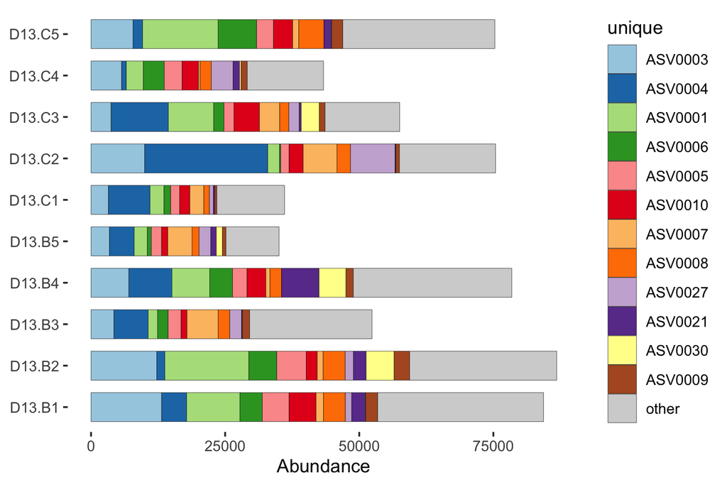

```r
mice %>%
  ps_filter(treatment_days == 'D13', virus == 'WNV2000', treatment == 'Vehicle') %>%
  comp_barplot(
    tax_level = 'unique', n_taxa = 12, bar_width = 0.7,
    sample_order = 'asis', tax_transform_for_plot = 'identity'
  ) +
  coord_flip()
```

What is going on here?? The unique taxa have uninformative IDs, and we also got a message about problems with the taxonomy table.

The total number of reads also varies a lot between samples! The total number of reads for each sample is NOT a reliable indicator of the biomass or bacterial load of each sample. So for now we will just consider the relative abundance of each taxon, as proportions of the total counts for that sample.

### Compositions (%)

```
## NAs detected in phyloseq tax_table:
## Consider using tax_fix() to make taxa uniquely identifiable
## NAs detected in phyloseq tax_table:
## Consider using tax_fix() to make taxa uniquely identifiable
```

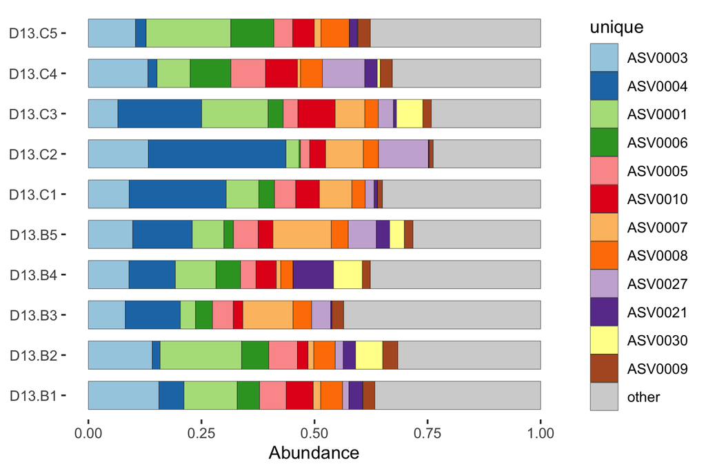

```r
mice %>%
  ps_filter(treatment_days == 'D13', virus == 'WNV2000', treatment == 'Vehicle') %>%
  comp_barplot(
    tax_level = 'unique', n_taxa = 12, sample_order = 'asis', bar_width = 0.7
  ) +
  coord_flip()
```

### Fixing tax_table

Let’s look at the taxonomy table interactively

```r
# tax_fix_interactive(mice) # run this in the R Console for an interactive look
```

Looks like we just need to fill in some blank cells when a sequence was not classified at genus or family. `tax_fix` can do this, it just copies down info from a higher rank classification. Let’s update our `mice` phyloseq object with this fix.

```r
mice <- tax_fix(mice, verbose = FALSE)
```

We can also rename the unique taxa with a more informative name, according to their classification at the rank of Family (and how common they are).

```r
mice %>% taxa_names() %>% head
```

```
## [1] "ASV0001" "ASV0002" "ASV0003" "ASV0004" "ASV0005" "ASV0006"
```

```r
mice <- tax_rename(mice, rank = 'Family')
mice %>% taxa_names() %>% head
```

```
## [1] "Porphyromonadaceae 001" "Xanthomonadaceae 01"    "Porphyromonadaceae 002"
## [4] "Porphyromonadaceae 003" "Porphyromonadaceae 004" "Porphyromonadaceae 005"
```

Let’s try again with the better names.

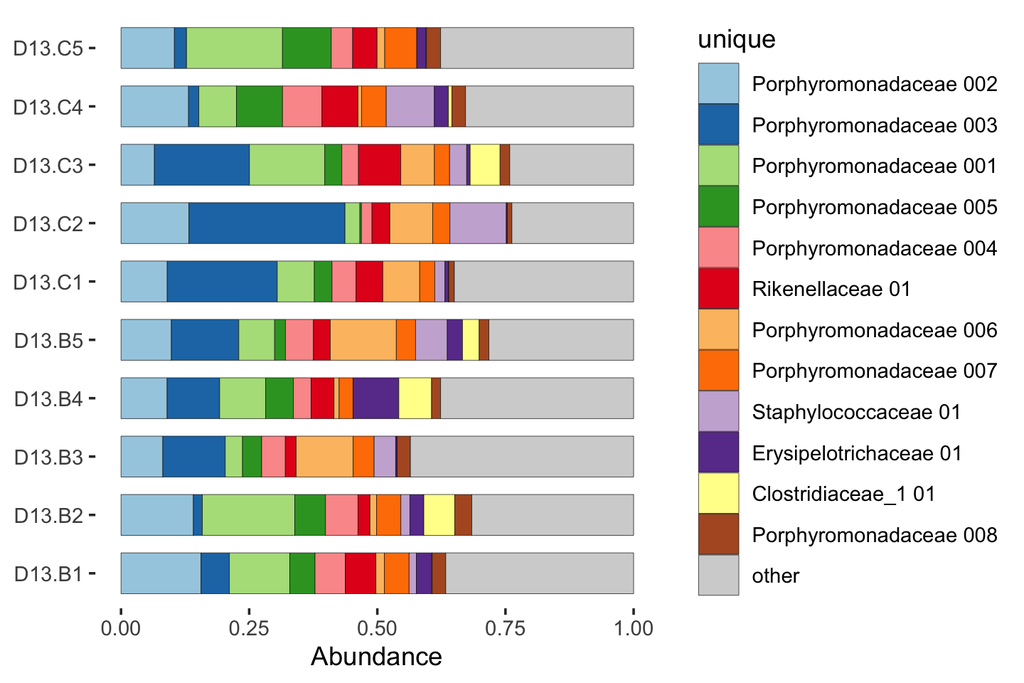

```r
mice %>%
  ps_filter(treatment_days == 'D13', virus == 'WNV2000', treatment == 'Vehicle') %>%
  comp_barplot(
    tax_level = 'unique', n_taxa = 12, sample_order = 'asis', bar_width = 0.7
    ) +
  coord_flip()
```

Sadly we don’t have enough distinct colours to show all the unique taxa.

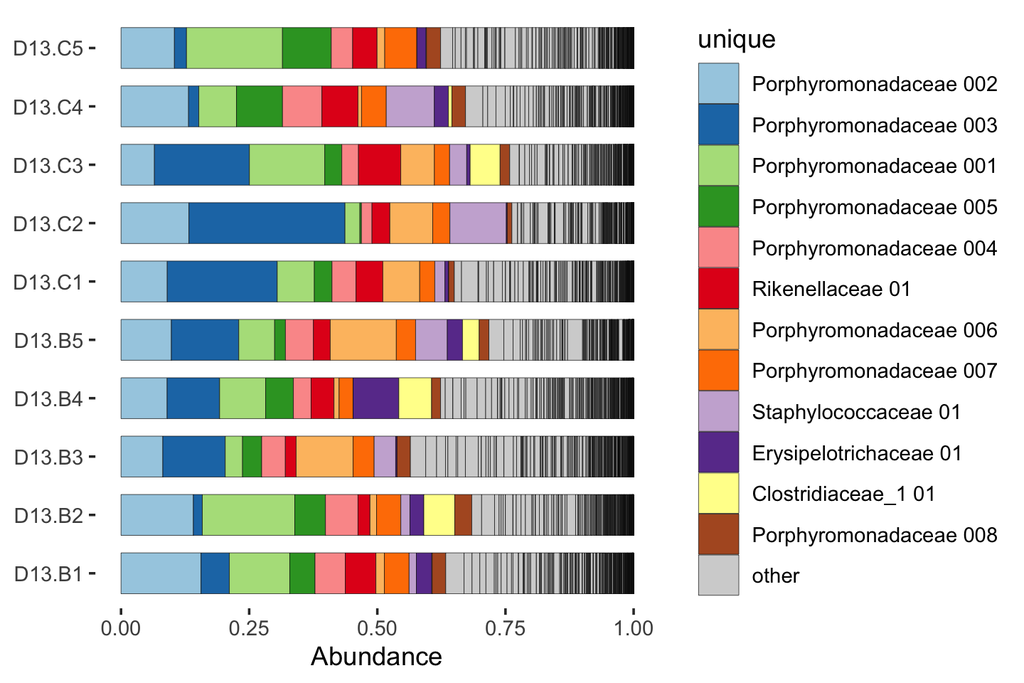

```r
mice %>%
  ps_filter(treatment_days == 'D13', virus == 'WNV2000', treatment == 'Vehicle') %>%
  comp_barplot(
    tax_level = 'unique', n_taxa = 12, sample_order = 'asis', bar_width = 0.7,
    merge_other = FALSE
    ) +
  coord_flip()
```

### Aggregating taxa

So let’s “aggregate” all the counts into family-level groups. For each family, this adds together all the counts from every ASV that belongs to that family. We can do that by changing the `tax_level` argument to “Family”.

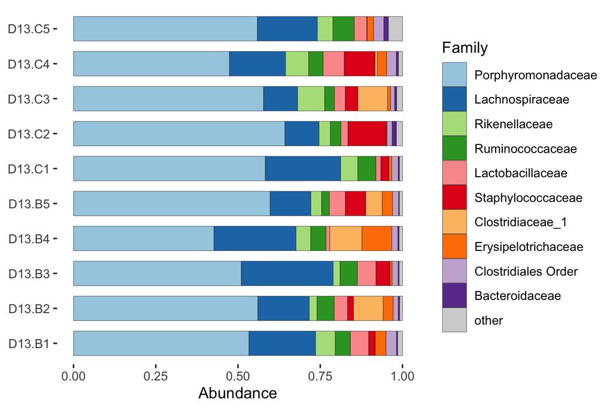

```r
mice %>%
  ps_filter(treatment_days == 'D13', virus == 'WNV2000', treatment == 'Vehicle') %>%
  comp_barplot(
    tax_level = "Family", n_taxa = 10, bar_width = 0.7, sample_order = 'asis'
  ) +
  coord_flip()
```

By aggregating at family level, we have sacrificed taxonomic resolution, compared to using ASVs. But this way we can get an idea of which families are the most abundant, and how variable the communities are.

Try making some similar plots aggregated at different taxonomic ranks.

```r
# rank_names(mice)
# mice %>%
#   ps_filter(treatment_days == 'D13', virus == 'WNV2000', treatment == 'Vehicle') %>%
#   comp_barplot(tax_level = , n_taxa = 10, sample_order = 'asis', merge_other = FALSE)
```

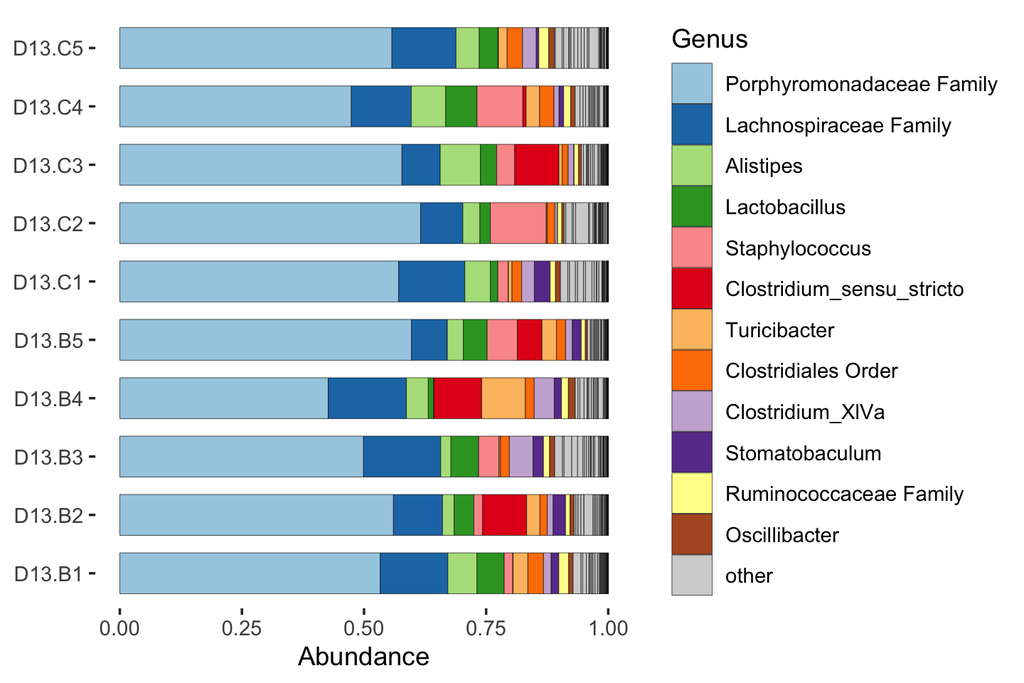

```r
mice %>%
  ps_filter(treatment_days == 'D13', virus == 'WNV2000', treatment == 'Vehicle') %>%
  comp_barplot(
    tax_level = "Genus", n_taxa = 12, bar_width = 0.7,
    sample_order = 'asis', merge_other = FALSE
  ) +
  coord_flip()
```

Many of the ASVs in this mice data, the *Porphyromonadaceae*, could not be classified at genus level.

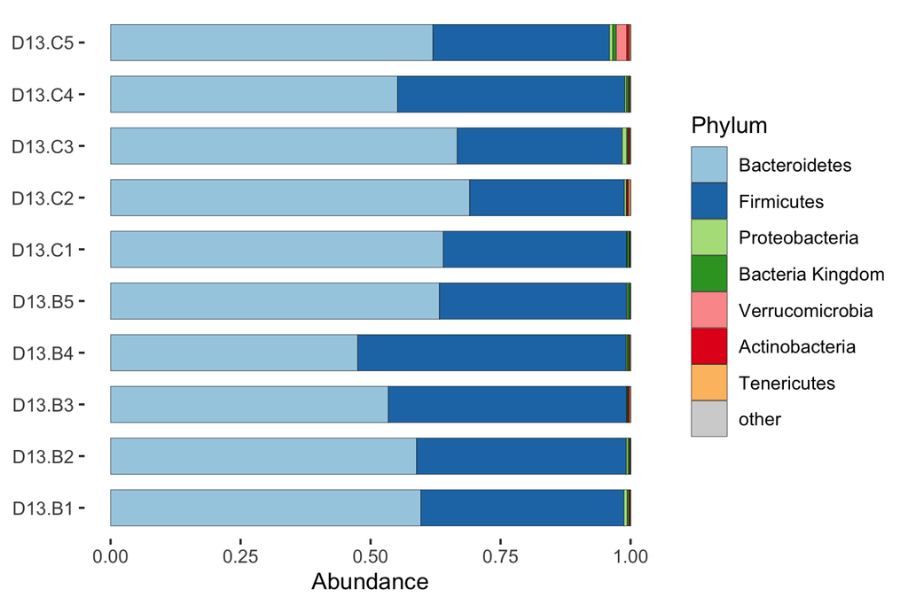

```r
mice %>%
  ps_filter(treatment_days == 'D13', virus == 'WNV2000', treatment == 'Vehicle') %>%
  comp_barplot(
    tax_level = "Phylum", n_taxa = 7, bar_width = 0.7, sample_order = 'asis'
  ) +
  coord_flip()
```

### Fickle Phyla

A note on phylum names! There have been major changes this year and some of these are now old names. Most published research is of course with the old names (and still probably will be for a year or so).

# Fun with barcharts

More examples/tutorial of visualizing microbiome data using stacked barcharts can be found here: https://david-barnett.github.io/microViz/articles/web-only/compositions.html

Try it out for yourself a bit!

Bar charts often look better when you sort the samples by similarity. The webpage mentions using Bray-Curtis distances and hierarchical clustering to sort samples. We haven’t discussed dissimilarity or distances yet, but we will in the next session today!

For now, just appreciate that it can make the bar charts easier to read!

# Alpha diversity

How diverse is the bacterial microbiome of each sample?

## Why is this interesting?

### Biologically

- Lower gut microbiome diversity is related to worse health in adult humans.
- Higher diversity ecosystems are often considered healthier, more mature, and more resilient to perturbation.
- BUT: diverse == healthy does not hold for all ecosystems, e.g. early infant gut microbiome, so consider your own data and hypotheses carefully.

### Practically

Diversity indices provide a simple one number summary of each ecosystem: easy to compare and do stats with.

## Richness

The more the merrier. The simplest measure is just counting, aka “Observed Richness”. Let’s compute the observed richness and label each sample with it.

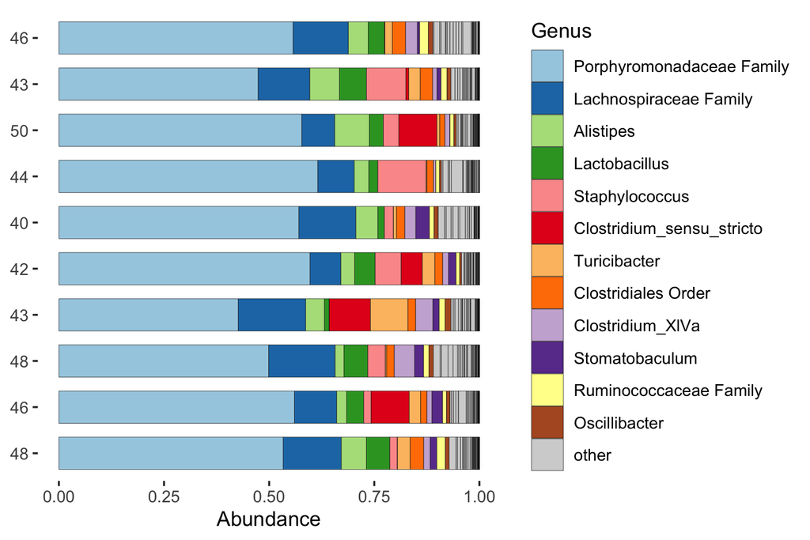

```r
mice %>%
  ps_filter(treatment_days == 'D13', virus == 'WNV2000', treatment == 'Vehicle') %>%
  ps_calc_richness(rank = 'Genus', index = 'observed', varname = 'N genera') %>%
  comp_barplot(
    tax_level = "Genus", n_taxa = 12, label = 'N genera', bar_width = 0.7,
    sample_order = 'asis', merge_other = FALSE#, tax_transform_for_plot = 'identity'
  ) +
  coord_flip()
```

## Diversity

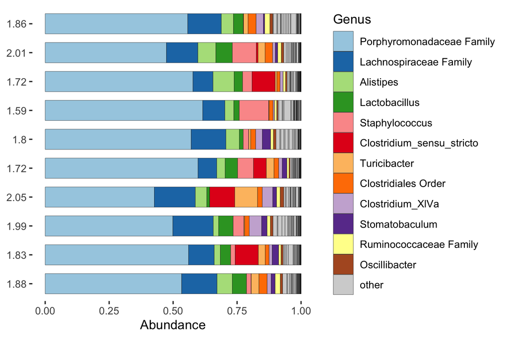

```r
mice %>%
  ps_filter(treatment_days == 'D13', virus == 'WNV2000', treatment == 'Vehicle') %>%
  ps_calc_diversity(rank = 'Genus', index = 'shannon') %>%
  ps_mutate(shannon_Genus = round(shannon_Genus, digits = 2)) %>%
  comp_barplot(
    tax_level = "Genus", n_taxa = 12, label = 'shannon_Genus', bar_width = 0.7,
    sample_order = 'asis', merge_other = FALSE
  ) +
  coord_flip()
```

## Statistics with alpha diversity

So we have our alpha diversity values for this small subset of mice.

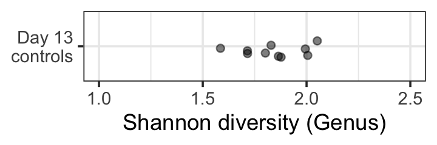

```r
mice %>%
  ps_filter(treatment_days == 'D13', virus == 'WNV2000', treatment == 'Vehicle') %>%
  ps_calc_diversity(rank = 'Genus', index = 'shannon') %>%
  samdat_tbl() %>%
  ggplot(aes(x = shannon_Genus, y = "Day 13\ncontrols")) +
  geom_point(position = position_jitter(height = 0.2), alpha = 0.5) +
  labs(x = 'Shannon diversity (Genus)', y = NULL) +
  xlim(1, 2.5) +
  theme_bw()
```

```r
# First compute a new variable aggregating all the control mice together
mice <- mice %>%
  ps_mutate(antibiotics = treatment %in% c("Amp", "Metro", "AmpMetro"))
```

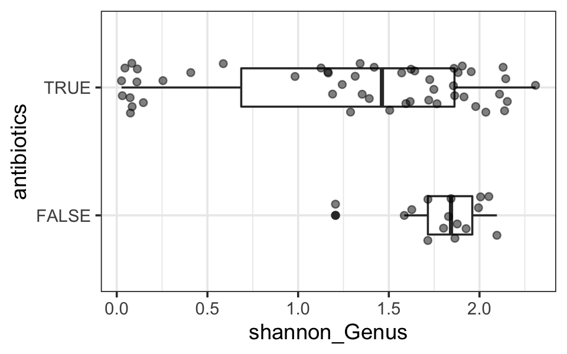

```r
mice %>%
  ps_filter(treatment_days == 'D13') %>%
  ps_calc_diversity(rank = 'Genus', index = 'shannon') %>%
  samdat_tbl() %>%
  ggplot(aes(y = antibiotics, x = shannon_Genus)) +
  geom_boxplot(width = 0.3) +
  geom_point(position = position_jitter(height = 0.2), alpha = 0.5) +
  theme_bw()
```

It looks like the antibiotics treated mice have lower gut microbiota diversity on average. A simple statistical test supports this.

```r
mice %>%
  ps_filter(treatment_days == 'D13') %>%
  ps_calc_diversity(rank = 'Genus', index = 'shannon') %>%
  samdat_tbl() %>%
  wilcox.test(formula = shannon_Genus ~ antibiotics, data = .)
```

```
##
##  Wilcoxon rank sum test with continuity correction
##
## data:  shannon_Genus by antibiotics
## W = 533, p-value = 0.0142
## alternative hypothesis: true location shift is not equal to 0
```

You can apply more complex statistical tests as you like, e.g. adjusting for covariates with linear regression, using `lm()`

```r
mice %>%
  ps_filter(treatment_days == 'D13') %>%
  ps_calc_diversity(rank = 'Genus', index = 'shannon') %>%
  samdat_tbl() %>%
  lm(formula = shannon_Genus ~ antibiotics + virus, data = .) %>%
  summary()
```

```
##
## Call:
## lm(formula = shannon_Genus ~ antibiotics + virus, data = .)
##
## Residuals:
##      Min       1Q   Median       3Q      Max
## -1.34105 -0.20830  0.08928  0.48767  1.25856
##
## Coefficients:
##                 Estimate Std. Error t value Pr(>|t|)
## (Intercept)       1.5947     0.2036   7.831 7.76e-11 ***
## antibioticsTRUE  -0.5445     0.1908  -2.854  0.00587 **
## virusWNV2000      0.3217     0.1742   1.847  0.06956 .
## ---
## Signif. codes:  0 '***' 0.001 '**' 0.01 '*' 0.05 '.' 0.1 ' ' 1
##
## Residual standard error: 0.6479 on 62 degrees of freedom
## Multiple R-squared:  0.1535, Adjusted R-squared:  0.1262
## F-statistic: 5.622 on 2 and 62 DF,  p-value: 0.005706
```

Try it out for yourself at other time points? Practice making plots and doing simple statistical tests.

What about richness?

## Extension exercises

**Click here for an extension activity with an IBD dataset:**

This is an extension exercise, for those who are moving quickly.

**Inflammatory Bowel Disease study**

```r
ibd <- corncob::ibd_phylo %>%
  tax_mutate(Species = NULL) %>% # ibd_phylo Species column was blank -> deleted
  ps_mutate(disease = ibd == 'ibd', ibd = NULL) # adds disease state indicator variable
```

`ibd` is another phyloseq object containing 16S rRNA gene amplicon sequencing data, from a 2012 study of Inflammatory Bowel Disease in children and young adults.

It’s “old” data: they used 454 Pyrosequencing, and clustered the raw sequences into “OTUs”.

Have a look at the data, like we did before for the `mice` dataset.

```r
ibd
```

```
## phyloseq-class experiment-level object
## otu_table()   OTU Table:         [ 36349 taxa and 91 samples ]
## sample_data() Sample Data:       [ 91 samples by 15 sample variables ]
## tax_table()   Taxonomy Table:    [ 36349 taxa by 6 taxonomic ranks ]
```

```r
#
```

You can perform alpha diversity analysis: Try comparing the alpha diversity of the IBD patients against the healthy controls.

```r
#
```

**Click here for additional notes on richness and readcount**

**Additional notes on richness and readcount**

Simple approaches like Observed Richness are sensitive to what ecologists call “sampling effort”. For macroecologists, this is actually how much time/effort you spent trying to count all the organisms present in an ecosystem. In our case, the amount of total reads obtained represents the sampling effort: more reads, more effort. Indeed we can see that the samples with a much lower readcount have lower observed richness.

(Furthermore, as this richness estimate is based on a sample, and not the actual ecosystem, the richness estimate actually has quantifiable uncertainty too.)

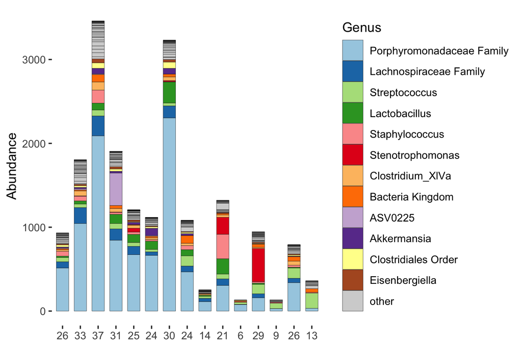

```r
mice %>%
  ps_filter(treatment_days == 'D13', virus == 'WNV2000', treatment == 'Amp') %>%
  ps_calc_richness(rank = 'Genus', index = 'observed', varname = 'N genera') %>%
  comp_barplot(
    tax_level = "Genus", n_taxa = 12, label = 'N genera', bar_width = 0.7,
    sample_order = 'asis', merge_other = FALSE, tax_transform_for_plot = 'identity'
  )
```

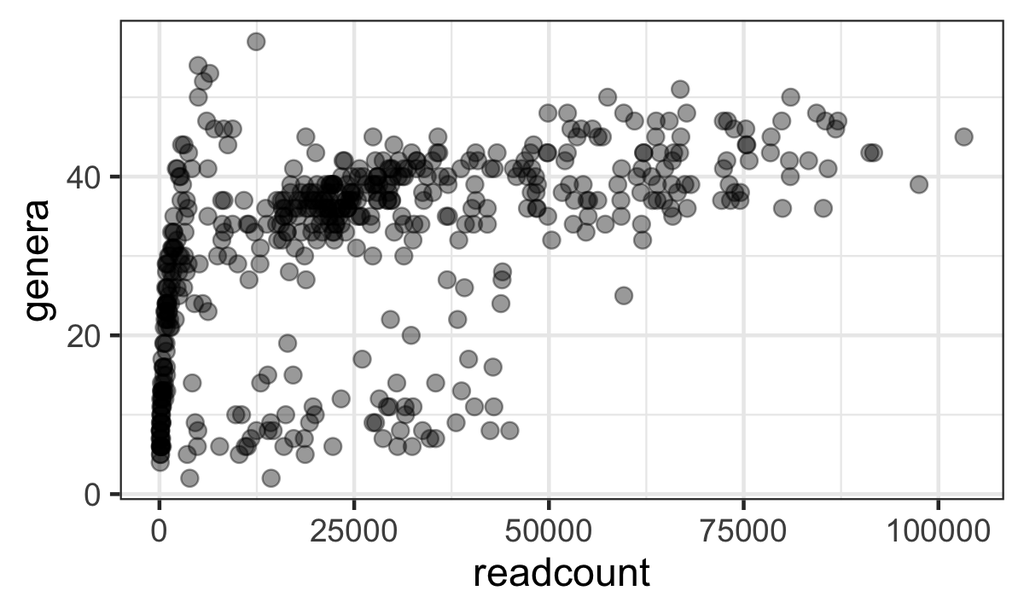

```r
mice %>%
  ps_calc_richness(rank = 'Genus', index = 'observed', varname = 'genera') %>%
  ps_mutate(readcount = sample_sums(mice)) %>%
  samdat_tbl() %>%
  ggplot(aes(readcount, genera)) +
  geom_point(alpha = 0.4, size = 2.5) +
  theme_bw(14)
```

# Session info